# funTDA — Part A: functional network baseline (H3N2)

- Show All Code
- Hide All Code
- View Source

Persistence landscapes, FPCA, and functional permutation tests over the 17 GRNs

Author

Victoria Arroniz

Published

July 20, 2026

## Data

This analysis starts from 17 gene regulatory networks (GRNs) built from the transcriptomic response to an experimental H3N2 influenza infection (Higgins, Wu & Carey). Of the 17 subjects, 8 remained **asymptomatic** and 9 developed **symptoms**. Each network is a 250×250 adjacency matrix, weighted and **undirected** (symmetric).

**NoteStructural check of the data**

- Number of adjacency matrices found: **17** (8 asymptomatic + 9 symptomatic).
- Dimension of all matrices: **250 × 250** — OK.
- Maximum asymmetry `max(|A - A^T|)` over the 17 matrices: **0** (0 = perfectly symmetric / undirected).

Before turning to persistent homology, it is worth looking at the networks “by eye”. The figure below compares, for one asymptomatic and one symptomatic subject, a 60-node subgraph keeping only the highest-weight edges (threshold: 85th percentile of edge weights, same as in `make_figs.py`):

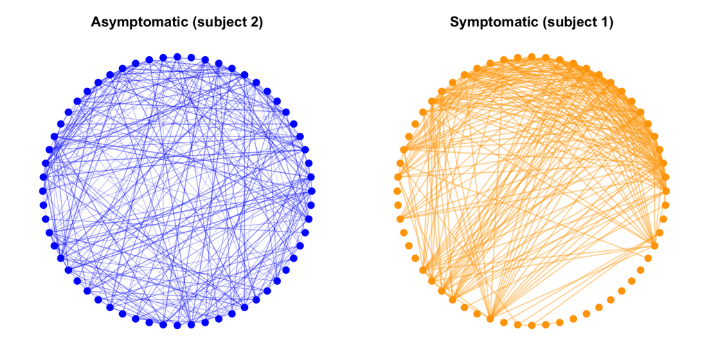

Persistence diagrams for each network (previously computed in Python with `giotto-tda`, see `funTDA.ipynb`) are precomputed in `output/PH/*.csv`, with columns `Birth, Death, dimension` and no header.

Inspecting the `dimension` column of the 17 persistence CSVs confirms that the only dimensions present are **0, 1** (H0 connected components and H1 loops). The baseline computes only H0 and H1 (the giotto-tda default, `homology_dimensions=(0,1)`), following funTDA; the analysis below therefore uses H1 landscapes (order `r`=1, first layer `KK`=1), replicating `funTDA.R`. The H2 / voids question is taken up with the image data, not the network baseline.

## Pipeline: from persistence diagrams to functional landscapes

The `landscape(..., KK = 1)` reimplementation was validated by comparing it bit-for-bit against `TDA::landscape` over the 17 subjects (maximum absolute difference = 0; see reproducible appendix). Curves are smoothed with an order-2 B-spline basis (`nbasis = 499`) over `tseq = seq(0, 1, length.out = 500)`, identical to `funTDA.R`.

### Example: persistence diagram and landscape of a representative subject

To illustrate the step from “persistence diagram” to “functional landscape”, a single representative subject is used — Symptomatic 1, the same one used in `make_figs.py` for `network_to_landscape.png` — and both representations are shown side by side, using the same `r_landscape1()` defined above.

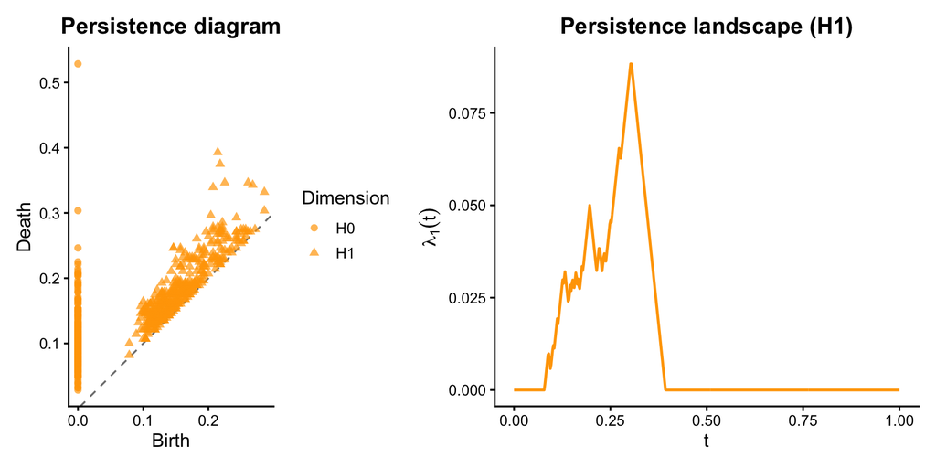

Representative subject (Symptomatic 1): H0/H1 persistence diagram (left) and H1 landscape $\lambda_1(t)$ (right).

### Landscapes by group

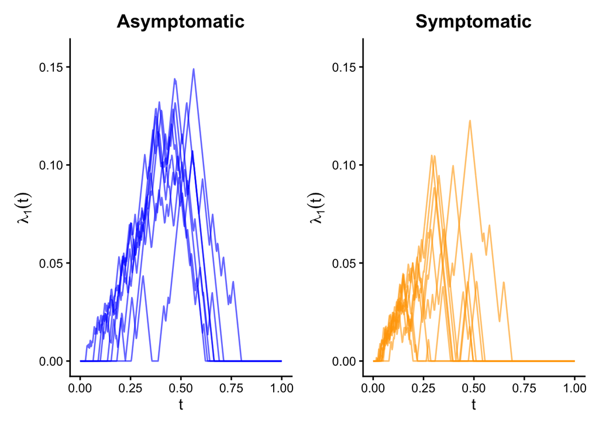

Individual H1 landscapes, one panel per group (same vertical scale). Asymptomatic subjects consistently occupy a band of higher peaks (~0.11–0.15), while symptomatic subjects are more variable and generally lower (~0.02–0.12) — a pattern consistent with the PC1 separation and with the permutation test (p = 0.0011).

## Functional Principal Component Analysis (FPCA)

Variance explained by the first two functional components

| Component | % variance explained |
| --- | --- |
| PC1 | 63.54% |
| PC2 | 19.99% |
| Cumulative (PC1+PC2) | 83.53% |

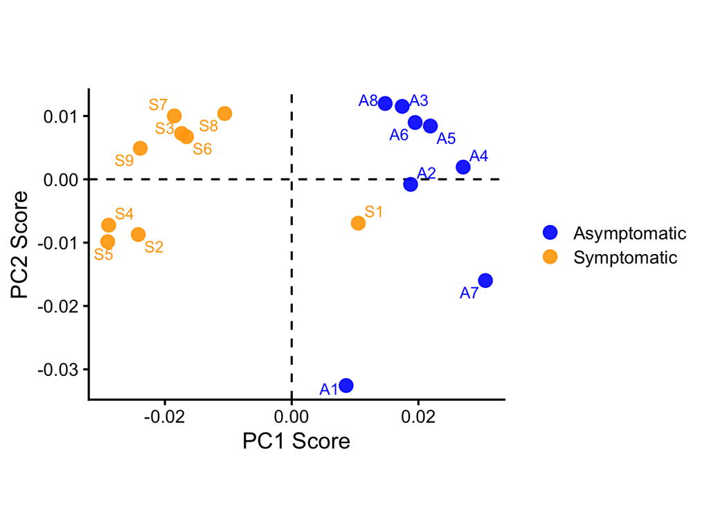

PC1 vs PC2 scores (FPCA over H1 landscapes), colored by group

**NoteFull FPC scores (all 17 subjects)**

| ID | Group | PC1 | PC2 |
| --- | --- | --- | --- |
| A1 | Asymptomatic | 0.0086 | -0.0326 |
| A2 | Asymptomatic | 0.0188 | -0.0008 |
| A3 | Asymptomatic | 0.0174 | 0.0115 |
| A4 | Asymptomatic | 0.0271 | 0.0019 |
| A5 | Asymptomatic | 0.0219 | 0.0084 |
| A6 | Asymptomatic | 0.0195 | 0.0090 |
| A7 | Asymptomatic | 0.0306 | -0.0160 |
| A8 | Asymptomatic | 0.0148 | 0.0120 |
| S1 | Symptomatic | 0.0105 | -0.0069 |
| S2 | Symptomatic | -0.0242 | -0.0087 |
| S3 | Symptomatic | -0.0174 | 0.0072 |
| S4 | Symptomatic | -0.0289 | -0.0072 |
| S5 | Symptomatic | -0.0290 | -0.0098 |
| S6 | Symptomatic | -0.0166 | 0.0067 |
| S7 | Symptomatic | -0.0185 | 0.0100 |
| S8 | Symptomatic | -0.0106 | 0.0104 |
| S9 | Symptomatic | -0.0239 | 0.0049 |

**NoteAcceptance criteria — FPCA (baseline vs. recomputed)**

| Metric | Reference | Recomputed |
| --- | --- | --- |
| PC1 | 63.5% | 63.54% |
| PC2 | 20.0% | 19.99% |
| Cumulative | 83.5% | 83.53% |
| Asymptomatic with PC1 > 0 | 8 / 8 | 8 / 8 |
| Symptomatic with PC1 < 0 | 8 / 9 | 8 / 9 |

The first two functional components explain **83.5%** of the variability among landscapes (PC1 $\approx$ 63.5%, PC2 $\approx$ 20.0%). In the PC1–PC2 plane, all 8 asymptomatic subjects fall in the PC1 > 0 half-plane, while 8 of the 9 symptomatic subjects fall in PC1 < 0: **one of the symptomatic subjects** (labeled here in a purely positional way — the `DataAsymp`/`DataSymp` construction in the `landscape-functions` chunk above prepends (`cbind(x1, Data)`) each new network to those already accumulated, reversing the order within each group relative to the file ID, so the “S1..S9” label should not be read as the subject’s real ID without separately verifying it. `funTDA.R` was later fixed to build these in ascending file-ID order with labels derived from the real ID; this document keeps the original prepend-based construction so the numbers below continue to match the validated baseline) overlaps with the asymptomatic region. PC1 separates the two groups reasonably well; PC2 shows no clear separation.

## Functional permutation test: asymptomatic vs. symptomatic

To avoid relying on `tperm.fd` with `nperm = 10000` (~40 s per test, infeasible for the 196 split-half tests), a vectorized version of the **same test** is used: it evaluates each functional object on the same grid `tperm.fd` uses by default (`argvals = seq(0, 1, length.out = 101)`) and permutes columns of a matrix instead of re-evaluating `fd` on every permutation. It was validated to reproduce `tperm.fd` **bit-for-bit** with the same seed (see appendix).

**ImportantAsymptomatic vs. Symptomatic test result**

- **p-value** = 0.0011 (reference: 0.0011)
- **Observed T_max** = 6.88 (reference: 6.88)
- **Critical value (95%)** = 3.72 (reference: 3.72)

With `T_max` = 6.88 well above the 95% critical value (3.72) and a p-value of 0.0011, the null hypothesis of functional equality between the mean H1 landscapes of asymptomatic and symptomatic subjects is rejected: **network topologies differ statistically significantly between the two groups.**

## Split-half validation (test calibration)

If the permutation test is well calibrated, randomly splitting **the same group** into two halves and comparing them against each other should yield p-values approximately uniformly distributed on [0, 1] — that is, equality should not be rejected more often than the nominal level (5%). This is checked exhaustively by considering **all** possible partitions of each group:

Summary of the split-half validation by group

| Group | mean p-value | sd(p-value) | % splits with p < 0.05 |
| --- | --- | --- | --- |
| Symptomatic (126 splits, 4 vs 5) | 0.498 | 0.290 | 5.6% |
| Asymptomatic (70 splits, 4 vs 4) | 0.490 | 0.291 | 5.7% |

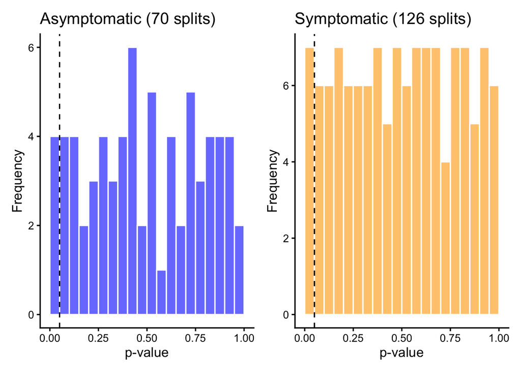

Distribution of split-half p-values, by group (dashed line at p = 0.05)

**NoteAcceptance criteria — split-half (baseline vs. recomputed)**

| Metric | Reference | Recomputed |
| --- | --- | --- |
| Symptomatic — mean p | 0.496 | 0.498 |
| Symptomatic — sd p | 0.290 | 0.290 |
| Symptomatic — % p < 0.05 | 5.6% | 5.6% |
| Asymptomatic — mean p | 0.481 | 0.490 |
| Asymptomatic — sd p | 0.291 | 0.291 |
| Asymptomatic — % p < 0.05 | 5.7% | 5.7% |

These quantities are Monte Carlo estimates (`nperm = 10000` per split) aggregated over dozens of partitions, so variation of this kind is expected relative to the baseline even when reproducing the algorithm exactly — in fact, the main test above (computed with the same seed, in the same order) reproduces the reference p-value exactly, and `vtperm` was validated bit-for-bit against `tperm.fd`. That is why the tolerance here is looser than in the main test.

In both groups, the fraction of splits with p < 0.05 (5.6% symptomatic, 5.7% asymptomatic) is consistent with the nominal 5% expected under H0, and mean p-values hover around 0.5 — the test does **not** produce systematic false positives when comparing sub-samples of the same group, which calibrates the significance reported for the asymptomatic–symptomatic contrast in the previous section.

## Appendix

### Validation of the `landscape(..., KK = 1)` reimplementation

```r
library(TDA)
tseq <- seq(0, 1, length.out = 500)
maxdiff <- 0
for (f in ph_files) {
  PH <- read.csv(f, header = FALSE)
  colnames(PH) <- c("Birth", "Death", "dimension")
  PHm <- as.matrix(PH[c("dimension", "Birth", "Death")])
  ref_landscape  <- landscape(PHm, dimension = 1, KK = 1, tseq)
  mine_landscape <- r_landscape1(PH, dim = 1, tseq = tseq)
  maxdiff <- max(maxdiff, max(abs(ref_landscape - mine_landscape)))
}
maxdiff  # 0 across the 17 subjects
```

### Validation of `vtperm` against `tperm.fd`

```r
set.seed(123)
ref_test  <- tperm.fd(fdAsymp, fdSymp, nperm = 500, q = 0.05, plotres = FALSE)
set.seed(123)
mine_test <- vtperm(cbind(eval.fd(argvals, fdAsymp), eval.fd(argvals, fdSymp)),
                     1:8, 9:17, nperm = 500)
isTRUE(all.equal(ref_test$pval, mine_test$pval)) # TRUE
isTRUE(all.equal(ref_test$Tobs, mine_test$Tobs)) # TRUE
```

### Full code (reproducible)

```r
library(fda)
library(ggplot2)
library(ggrepel)
library(patchwork)
library(igraph)

# Baseline reference values (for comparison only, NOT shown as a result:
# every number reported in the body of the document is recomputed from the
# CSVs committed under output/PH and data/GRN_adjacency_matrices).
ref <- list(
  pc1_pct = 63.5, pc2_pct = 20.0,
  test1_p = 0.0011, test1_Tobs = 6.88, test1_crit95 = 3.72,
  symp_mean = 0.496, symp_sd = 0.290, symp_frac05 = 5.6,
  asymp_mean = 0.481, asymp_sd = 0.291, asymp_frac05 = 5.7
)

# Unified color palette for all figures in the document
col_asymp <- "blue"
col_symp  <- "orange"
adj_dir <- "../data/GRN_adjacency_matrices"
adj_files <- list.files(adj_dir, full.names = TRUE)

adj_check <- lapply(adj_files, function(f) as.matrix(read.csv(f, header = FALSE)))
dims_ok <- all(vapply(adj_check, function(m) all(dim(m) == c(250, 250)), logical(1)))
max_asym <- max(vapply(adj_check, function(m) max(abs(m - t(m))), numeric(1)))

stopifnot(
  "Expected 17 adjacency matrices" = length(adj_files) == 17,
  "All matrices must be 250x250" = dims_ok,
  "All matrices must be symmetric (undirected)" = max_asym == 0
)
build_thresholded_graph <- function(adj_path, n_nodes = 60, seed = 0) {
  adj <- as.matrix(read.csv(adj_path, header = FALSE))
  set.seed(seed)
  nodes <- sort(sample(seq_len(nrow(adj)), n_nodes))
  sub <- adj[nodes, nodes]
  thr <- quantile(sub[upper.tri(sub)], 0.85)
  adj_thr <- sub
  adj_thr[adj_thr <= thr] <- 0
  igraph::graph_from_adjacency_matrix(adj_thr, mode = "upper", weighted = TRUE, diag = FALSE)
}

gA <- build_thresholded_graph(file.path(adj_dir, "Asymptomaticadjmatrix2.csv"))
gS <- build_thresholded_graph(file.path(adj_dir, "Symptomaticadjmatrix1.csv"))

w_rng <- range(c(igraph::E(gA)$weight, igraph::E(gS)$weight))
edge_width <- function(g) 0.4 + 1.6 * (igraph::E(g)$weight - w_rng[1]) / diff(w_rng)

set.seed(1); layoutA <- igraph::layout_in_circle(gA)
set.seed(1); layoutS <- igraph::layout_in_circle(gS)

par(mfrow = c(1, 2), mar = c(1, 1, 3, 1))
plot(gA, layout = layoutA, vertex.size = 5, vertex.label = NA,
     vertex.color = col_asymp, vertex.frame.color = col_asymp,
     edge.width = edge_width(gA), edge.color = grDevices::adjustcolor(col_asymp, alpha.f = 0.4),
     main = "Asymptomatic (subject 2)")
plot(gS, layout = layoutS, vertex.size = 5, vertex.label = NA,
     vertex.color = col_symp, vertex.frame.color = col_symp,
     edge.width = edge_width(gS), edge.color = grDevices::adjustcolor(col_symp, alpha.f = 0.4),
     main = "Symptomatic (subject 1)")
par(mfrow = c(1, 1))
ph_dir <- "../output/PH"
ph_files_raw <- list.files(ph_dir, pattern = "_PH.csv$", full.names = TRUE)

all_dims <- unlist(lapply(ph_files_raw, function(f) {
  d <- read.csv(f, header = FALSE)
  unique(d[[3]])
}))
unique_dims <- sort(unique(all_dims))

stopifnot(
  "Persistence diagrams should only contain dimensions 0 and 1" =
    identical(unique_dims, c(0, 1))
)
tseq <- seq(0, 1, length.out = 500)

# Pure-R reimplementation of TDA::landscape(..., KK = 1): avoids the heavy
# TDA/GUDHI dependency. Formula (validated bit-for-bit against TDA::landscape,
# see appendix): lambda_1(t) = max_i max(0, min(t - b_i, d_i - t)) over the
# bars of the requested dimension.
r_landscape1 <- function(PH, dim = 1, tseq) {
  bd <- PH[PH$dimension == dim, c("Birth", "Death"), drop = FALSE]
  if (nrow(bd) == 0) return(rep(0, length(tseq)))
  b <- bd$Birth
  d <- bd$Death
  sapply(tseq, function(t) max(0, max(pmin(t - b, d - t))))
}

get_number <- function(fname) as.numeric(sub(".*adjmatrix([0-9]+)_PH.*", "\\1", fname))
ph_files <- ph_files_raw[order(sapply(ph_files_raw, get_number))]

DataSymp <- c()
DataAsymp <- c()
for (f in ph_files) {
  PH <- read.csv(f, header = FALSE)
  colnames(PH) <- c("Birth", "Death", "dimension")
  x1 <- r_landscape1(PH, dim = 1, tseq = tseq)

  fname <- basename(f)
  if (grepl("^Asymptomatic", fname)) {
    DataAsymp <- cbind(x1, DataAsymp)
  } else if (grepl("^Symptomatic", fname)) {
    DataSymp <- cbind(x1, DataSymp)
  }
}
DataSymp  <- t(DataSymp)
DataAsymp <- t(DataAsymp)
DataBoth  <- rbind(DataAsymp, DataSymp)

stopifnot(
  "Expected 8 asymptomatic subjects" = nrow(DataAsymp) == 8,
  "Expected 9 symptomatic subjects"  = nrow(DataSymp) == 9
)

# B-spline smoothing identical to funTDA.R: order-2 basis (piecewise linear),
# nbasis = Q - 1 = 499 knots over [0, 1].
create_fd <- function(Data) {
  x <- seq(0, 1, length.out = ncol(Data))
  basis <- create.bspline.basis(c(0, 1), nbasis = ncol(Data) - 1, norder = 2)
  fdobj <- smooth.basis(x, t(Data), basis)
  fdobj$fd
}

fdSymp  <- create_fd(DataSymp)
fdAsymp <- create_fd(DataAsymp)
fdBoth  <- create_fd(DataBoth)
PH_s1 <- read.csv(file.path(ph_dir, "Symptomaticadjmatrix1_PH.csv"), header = FALSE)
colnames(PH_s1) <- c("Birth", "Death", "dimension")

diagram_plot <- ggplot(PH_s1, aes(x = Birth, y = Death, shape = factor(dimension))) +
  geom_abline(slope = 1, intercept = 0, linetype = "dashed", color = "grey50") +
  geom_point(size = 2, alpha = 0.7, color = col_symp) +
  scale_shape_manual(values = c("0" = 16, "1" = 17), name = "Dimension",
                      labels = c("H0", "H1")) +
  labs(x = "Birth", y = "Death", title = "Persistence diagram") +
  coord_equal() +
  theme_classic(base_size = 13) +
  theme(plot.title = element_text(hjust = 0.5, face = "bold"))

ls_s1 <- r_landscape1(PH_s1, dim = 1, tseq = tseq)
landscape_plot <- ggplot(data.frame(t = tseq, lambda = ls_s1), aes(x = t, y = lambda)) +
  geom_line(color = col_symp, linewidth = 0.9) +
  labs(x = "t", y = expression(lambda[1](t)), title = "Persistence landscape (H1)") +
  theme_classic(base_size = 13) +
  theme(plot.title = element_text(hjust = 0.5, face = "bold"))

diagram_plot + landscape_plot
indiv_list <- list()
for (i in seq_len(nrow(DataAsymp))) {
  indiv_list[[length(indiv_list) + 1]] <- data.frame(
    t = tseq, lambda = DataAsymp[i, ], subject = paste0("A", i), Group = "Asymptomatic"
  )
}
for (i in seq_len(nrow(DataSymp))) {
  indiv_list[[length(indiv_list) + 1]] <- data.frame(
    t = tseq, lambda = DataSymp[i, ], subject = paste0("S", i), Group = "Symptomatic"
  )
}
indiv_df <- do.call(rbind, indiv_list)
y_max <- max(indiv_df$lambda) * 1.05
```

```r
plot_group_landscapes <- function(df, group_label, col) {
  ggplot(df, aes(x = t, y = lambda, group = subject)) +
    geom_line(color = col, alpha = 0.6, linewidth = 0.6) +
    scale_y_continuous(limits = c(0, y_max)) +
    labs(x = "t", y = expression(lambda[1](t)), title = group_label) +
    theme_classic(base_size = 13) +
    theme(plot.title = element_text(hjust = 0.5, face = "bold"))
}

plot_asymp <- plot_group_landscapes(indiv_df[indiv_df$Group == "Asymptomatic", ], "Asymptomatic", col_asymp)
plot_symp  <- plot_group_landscapes(indiv_df[indiv_df$Group == "Symptomatic", ], "Symptomatic", col_symp)

plot_asymp + plot_symp
pca <- pca.fd(fdBoth, nharm = 2)

pc1_pct <- pca$varprop[1] * 100
pc2_pct <- pca$varprop[2] * 100
cum_pct <- pc1_pct + pc2_pct

m <- c("A1", "A2", "A3", "A4", "A5", "A6", "A7", "A8",
       "S1", "S2", "S3", "S4", "S5", "S6", "S7", "S8", "S9")
group <- c(rep("Asymptomatic", 8), rep("Symptomatic", 9))

pca_df <- data.frame(
  PC1 = pca$scores[, 1],
  PC2 = pca$scores[, 2],
  ID = m,
  Group = group
)

n_asymp_pos <- sum(pca_df$PC1[pca_df$Group == "Asymptomatic"] > 0)
n_symp_neg  <- sum(pca_df$PC1[pca_df$Group == "Symptomatic"] < 0)
knitr::kable(
  data.frame(
    Component = c("PC1", "PC2", "Cumulative (PC1+PC2)"),
    `% variance explained` = c(sprintf("%.2f%%", pc1_pct), sprintf("%.2f%%", pc2_pct), sprintf("%.2f%%", cum_pct)),
    check.names = FALSE
  ),
  align = "lr"
)
ggplot(pca_df, aes(x = PC1, y = PC2, color = Group, label = ID)) +
  geom_hline(yintercept = 0, linetype = "dashed", color = "black") +
  geom_vline(xintercept = 0, linetype = "dashed", color = "black") +
  geom_point(size = 4, alpha = 0.9) +
  ggrepel::geom_text_repel(size = 4, show.legend = FALSE, max.overlaps = Inf) +
  scale_color_manual(values = c("Asymptomatic" = col_asymp, "Symptomatic" = col_symp)) +
  labs(x = "PC1 Score", y = "PC2 Score", title = "") +
  coord_fixed() +
  theme_classic(base_size = 16) +
  theme(
    legend.position = "right",
    legend.title = element_blank(),
    plot.title = element_text(hjust = 0.5, face = "bold")
  )
pca_full_df <- data.frame(
  ID = pca_df$ID,
  Group = pca_df$Group,
  PC1 = round(pca_df$PC1, 4),
  PC2 = round(pca_df$PC2, 4)
)
knitr::kable(pca_full_df, align = "llrr")
tol_fpca <- 0.1  # percentage points
stopifnot(
  "PC1 out of tolerance relative to baseline" = abs(pc1_pct - ref$pc1_pct) < tol_fpca,
  "PC2 out of tolerance relative to baseline" = abs(pc2_pct - ref$pc2_pct) < tol_fpca,
  "Expected all 8 asymptomatic subjects with PC1 > 0" = n_asymp_pos == 8,
  "Expected exactly 8 of 9 symptomatic subjects with PC1 < 0" = n_symp_neg == 8
)
rowVar <- function(M) {
  n <- ncol(M)
  mu <- rowMeans(M)
  rowSums((M - mu)^2) / (n - 1)
}

vtperm <- function(X, i1, i2, nperm = 10000) {
  x1 <- X[, i1, drop = FALSE]
  x2 <- X[, i2, drop = FALSE]
  n1 <- ncol(x1); n2 <- ncol(x2)
  Xmat <- cbind(x1, x2)
  n <- n1 + n2
  Ts <- function(M) {
    m1 <- rowMeans(M[, 1:n1, drop = FALSE])
    m2 <- rowMeans(M[, n1 + (1:n2), drop = FALSE])
    v1 <- rowVar(M[, 1:n1, drop = FALSE]) / n1
    v2 <- rowVar(M[, n1 + (1:n2), drop = FALSE]) / n2
    max(abs(m1 - m2) / sqrt(v1 + v2))
  }
  Tobs <- Ts(Xmat)
  Tn <- numeric(nperm)
  for (i in 1:nperm) Tn[i] <- Ts(Xmat[, sample(n)])
  list(pval = mean(Tobs < Tn), Tobs = Tobs, crit95 = unname(quantile(Tn, 0.95)))
}
argvals <- seq(0, 1, length.out = 101)
cache_file <- "../output/results_partA_permtest_cache.rds"

if (file.exists(cache_file)) {
  cached <- readRDS(cache_file)
} else {
  set.seed(123)

  # 1) Main test: Asymptomatic vs Symptomatic
  XFull <- cbind(eval.fd(argvals, fdAsymp), eval.fd(argvals, fdSymp))
  test1 <- vtperm(XFull, 1:8, 9:17, nperm = 10000)

  # 2) Symptomatic split-half: combn(1:9, 4) = 126 4-vs-5 partitions
  XSymp <- eval.fd(argvals, fdSymp)
  splitsS <- combn(1:9, 4)
  pvalsS <- numeric(ncol(splitsS))
  for (i in seq_len(ncol(splitsS))) {
    g1 <- splitsS[, i]; g2 <- setdiff(1:9, g1)
    pvalsS[i] <- vtperm(XSymp, g1, g2, nperm = 10000)$pval
  }

  # 3) Asymptomatic split-half: combn(1:8, 4) = 70 4-vs-4 partitions.
  # Because the complement of a 4-of-8 subset is also a 4-of-8 subset, every
  # unique 4-vs-4 partition appears twice among these 70 (once with each
  # half as group1) — 35 unique partitions, each tested twice. Not
  # collapsed, to keep reproducing the baseline. The symptomatic loop above
  # (combn(1:9, 4), 4-vs-5) does not have this issue: a 5-element complement
  # is never itself drawn as a 4-element subset, so all 126 are distinct.
  XAsymp <- eval.fd(argvals, fdAsymp)
  splitsA <- combn(1:8, 4)
  pvalsA <- numeric(ncol(splitsA))
  for (i in seq_len(ncol(splitsA))) {
    g1 <- splitsA[, i]; g2 <- setdiff(1:8, g1)
    pvalsA[i] <- vtperm(XAsymp, g1, g2, nperm = 10000)$pval
  }

  cached <- list(test1 = test1, pvalsS = pvalsS, pvalsA = pvalsA)
  saveRDS(cached, cache_file)
}

test1  <- cached$test1
pvalsS <- cached$pvalsS
pvalsA <- cached$pvalsA

stopifnot(
  "Expected 126 symptomatic splits (combn(9,4))" = length(pvalsS) == 126,
  "Expected 70 asymptomatic splits (combn(8,4))" = length(pvalsA) == 70
)
tol_p <- 0.002
tol_T <- 0.05
stopifnot(
  "Main test p-value out of tolerance" = abs(test1$pval - ref$test1_p) < tol_p,
  "Observed Tmax out of tolerance" = abs(test1$Tobs - ref$test1_Tobs) < tol_T,
  "95% critical value out of tolerance" = abs(test1$crit95 - ref$test1_crit95) < tol_T
)
splithalf_summary <- data.frame(
  Group = c("Symptomatic (126 splits, 4 vs 5)", "Asymptomatic (70 splits, 4 vs 4)"),
  `mean p-value` = sprintf("%.3f", c(mean(pvalsS), mean(pvalsA))),
  `sd(p-value)` = sprintf("%.3f", c(sd(pvalsS), sd(pvalsA))),
  `% splits with p < 0.05` = sprintf("%.1f%%", c(mean(pvalsS < 0.05), mean(pvalsA < 0.05)) * 100),
  check.names = FALSE
)
knitr::kable(splithalf_summary, align = "lrrr")
histS <- ggplot(data.frame(p = pvalsS), aes(x = p)) +
  geom_histogram(binwidth = 0.05, boundary = 0, fill = col_symp, alpha = 0.6, color = "white") +
  geom_vline(xintercept = 0.05, linetype = "dashed", color = "black") +
  labs(title = "Symptomatic (126 splits)", x = "p-value", y = "Frequency") +
  theme_classic(base_size = 13)
```

```r
histA <- ggplot(data.frame(p = pvalsA), aes(x = p)) +
  geom_histogram(binwidth = 0.05, boundary = 0, fill = col_asymp, alpha = 0.6, color = "white") +
  geom_vline(xintercept = 0.05, linetype = "dashed", color = "black") +
  labs(title = "Asymptomatic (70 splits)", x = "p-value", y = "Frequency") +
  theme_classic(base_size = 13)

histA + histS
tol_mean <- 0.02
tol_sd   <- 0.02
tol_frac <- 2.0  # percentage points
stopifnot(
  "Symptomatic mean p out of tolerance"  = abs(mean(pvalsS) - ref$symp_mean) < tol_mean,
  "Symptomatic sd p out of tolerance"    = abs(sd(pvalsS) - ref$symp_sd) < tol_sd,
  "Symptomatic frac<0.05 out of tolerance" = abs(mean(pvalsS < 0.05) * 100 - ref$symp_frac05) < tol_frac,
  "Asymptomatic mean p out of tolerance" = abs(mean(pvalsA) - ref$asymp_mean) < tol_mean,
  "Asymptomatic sd p out of tolerance"   = abs(sd(pvalsA) - ref$asymp_sd) < tol_sd,
  "Asymptomatic frac<0.05 out of tolerance" = abs(mean(pvalsA < 0.05) * 100 - ref$asymp_frac05) < tol_frac
)
library(TDA)
tseq <- seq(0, 1, length.out = 500)
maxdiff <- 0
for (f in ph_files) {
  PH <- read.csv(f, header = FALSE)
  colnames(PH) <- c("Birth", "Death", "dimension")
  PHm <- as.matrix(PH[c("dimension", "Birth", "Death")])
  ref_landscape  <- landscape(PHm, dimension = 1, KK = 1, tseq)
  mine_landscape <- r_landscape1(PH, dim = 1, tseq = tseq)
  maxdiff <- max(maxdiff, max(abs(ref_landscape - mine_landscape)))
}
maxdiff  # 0 across the 17 subjects
set.seed(123)
ref_test  <- tperm.fd(fdAsymp, fdSymp, nperm = 500, q = 0.05, plotres = FALSE)
set.seed(123)
mine_test <- vtperm(cbind(eval.fd(argvals, fdAsymp), eval.fd(argvals, fdSymp)),
                     1:8, 9:17, nperm = 500)
isTRUE(all.equal(ref_test$pval, mine_test$pval)) # TRUE
isTRUE(all.equal(ref_test$Tobs, mine_test$Tobs)) # TRUE
```